# 第 15 章 无监督学习

第 5 至第 9 章介绍的所有算法都属于更大的监督学习工具类别。这类工具试图揭示预测变量 $\textbf{X}$ 与标签 $\textbf{Z}$ 之间的映射关系。“监督”来自这样一个事实：我们要求数据去解释这个特定变量 $\textbf{Z}$。机器学习中的另一项重要内容是无监督任务，也就是没有指定 $\textbf{Z}$ 时，算法尝试自行理解 $\textbf{X}$。通常，它会识别 $\textbf{X}$ 各组成部分之间的关系。这个领域过于庞大，一本书都难以概括，更不用说一章。本章的目的，是简要说明无监督学习可以如何使用，尤其是在数据预处理阶段。

## 15.1 相关预测变量的问题

人们常常想把所有预测变量都输入由机器学习驱动的预测引擎。当一些预测变量高度相关时，这未必是好主意。为说明这一点，最简单的例子是对两个零均值变量做回归，其协方差矩阵和精度矩阵为：

\begin{equation} \boldsymbol{\Sigma}=\textbf{X}'\textbf{X}=\begin{bmatrix} 1 & \rho \\ \rho & 1 \end{bmatrix}, \quad \boldsymbol{\Sigma}^{-1}=\frac{1}{1-\rho^2}\begin{bmatrix} 1 & -\rho \\ -\rho & 1 \end{bmatrix}. \end{equation}

当协方差/相关系数 $ρ$ 增大并趋近于 1（两个变量共线）时，$\boldsymbol{\Sigma}^{-1}$ 中的缩放分母趋近于零，而公式 $\hat{\boldsymbol{\beta}}=\boldsymbol{\Sigma}^{-1}\textbf{X}'\textbf{Z}$ 意味着一个系数会高度为正，另一个会高度为负。回归在两个变量之间制造了虚假的套利关系。当然，这非常低效，并会在样本外产生灾难性结果。

```python
import statsmodels.api as sm                                                               # Package for clean regression output

stat = sm.OLS(training_sample['R1M_Usd'],sm.add_constant(training_sample[features])).fit()  # Model: predict R1M_Usd
reg_thrhld=3                                                                                # Keep significant predictors only
boo_filter = np.abs(stat.tvalues) >= reg_thrhld                                             # regressors significance threshold
estimate=stat.params[boo_filter]                                                            # estimate
std_error=stat.bse[boo_filter]                                                              # std.error
statistic=stat.tvalues[boo_filter]                                                          # statistic
p_value=stat.pvalues[boo_filter]                                                            # p.value
significant_regressors = pd.concat([estimate,std_error,statistic,p_value],axis=1)           # Put output in clean format
significant_regressors.columns=['estimate','std.error','statistic','p.value']               # Renaming columns
print(significant_regressors)
```

```
                   estimate  std.error  statistic       p.value
const              0.040574   0.005343   7.594323  3.107512e-14
Ebitda_Margin      0.013237   0.003493   3.789999  1.506925e-04
Ev_Ebitda          0.006814   0.002256   3.020213  2.526288e-03
Fa_Ci              0.007231   0.002347   3.081471  2.060090e-03
Fcf_Bv             0.025054   0.005131   4.882465  1.048492e-06
Fcf_Yld           -0.015893   0.003736  -4.254127  2.099628e-05
Mkt_Cap_12M_Usd    0.204738   0.027432   7.463476  8.461142e-14
Mkt_Cap_6M_Usd    -0.179780   0.045939  -3.913443  9.101987e-05
Mom_5M_Usd        -0.018669   0.004431  -4.212972  2.521442e-05
Mom_Sharp_11M_Usd  0.017817   0.004695   3.795131  1.476096e-04
Ni                 0.015461   0.004497   3.438361  5.853680e-04
Ni_Avail_Margin    0.011814   0.003861   3.059359  2.218407e-03
Ocf_Bv            -0.019811   0.005294  -3.742277  1.824119e-04
Pb                -0.017897   0.003129  -5.720637  1.062777e-08
Pe                -0.008991   0.002354  -3.819565  1.337278e-04
Sales_Ps          -0.015786   0.004628  -3.411062  6.472325e-04
Vol1Y_Usd          0.011425   0.002792   4.091628  4.285247e-05
Vol3Y_Usd          0.008459   0.002795   3.026169  2.477060e-03
```

表 15.1：训练样本中的显著预测变量。

事实上，市值有多个指标，也许只需要其中一个即可，但很难直接判断哪一个是最佳选择。

为了进一步展示相关性问题，我们在下方计算预测变量的相关矩阵（基于训练样本）。由于维度较高，我们用图形方式呈现。

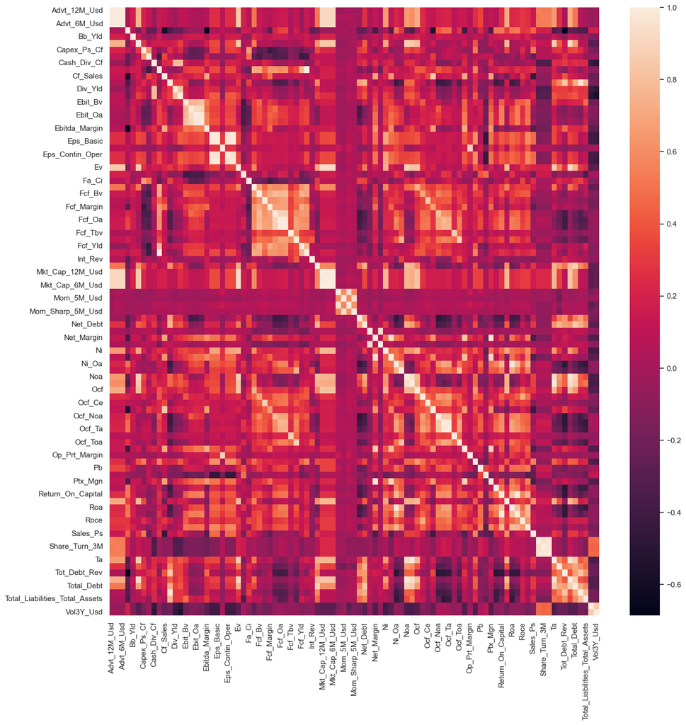

```python
import seaborn as sns                                                               # Package for plots
sns.set(rc={'figure.figsize':(16,16)})                                               # Setting the figsize in seaborn
sns.heatmap(training_sample[features].corr())                                       # Correlation matrix and plot
```

图 15.1：预测变量的相关矩阵。

图 15.1 显示，对角线附近有几个浅色方块。例如，特征前约三分之一位置附近最大的方块，涉及所有基于自由现金流的会计比率。由于这些特征在计算中有共同项，它们自然高度相关。这类局部相关模式在数据集中多次出现，也解释了为什么用这组特征做简单回归并不是好主意。

坦率地说，**多重共线性**（预测变量相关）对机器学习工具的影响，可能远小于它对纯统计推断的影响。在统计学中，一个核心目标是研究 $\beta$ 系数的性质。共线性会扰动这类分析。在机器学习中，目标是最大化样本外精度。如果许多预测变量有帮助，那就可以保留。一个简单例子有助于说明这一点。构建回归树时，更多预测变量会给分裂提供更多选择。如果特征有意义，它们就可能有用。随机森林和提升树同理。真正重要的是，大范围特征是否有助于提升模型泛化能力。它们之间的共线性并不相关。

在本章余下部分，我们介绍两种有助于减少预测变量数量的方法：

- 第一种方法旨在创建彼此不相关的新变量。从算法角度看，低相关性是有利的，但新变量缺乏可解释性；
- 第二种方法将预测变量归入同质聚类，并且只应从每个聚类中选择一个特征。这里的逻辑正好相反：相较于统计性质，更重视可解释性，因为最终得到的特征集合仍可能包含较高相关性，只是相比原始集合程度较低。

## 15.2 主成分分析与自编码器

第一种方法是降维中的基石。它试图确定较少数量的因子（$K'<K$），使得：

- i) 解释能力尽可能保持在较高水平；
- ii) 得到的因子是原始变量的线性组合；
- iii) 得到的因子相互正交。

### 15.2.1 一点代数

在这个简短小节中，我们定义若干关键概念，它们是完整理解主成分分析（PCA）推导所必需的。下文将使用矩阵（以粗体表示）。若 $I>K$ 且 $\textbf{X}'\textbf{X}=\textbf{I}_K$，则 $I \times K$ 矩阵 $\textbf{X}$ 是正交归一的。当 $I=K$ 时，该（方）矩阵称为正交矩阵，且 $\textbf{X}'\textbf{X}=\textbf{X}\textbf{X}'=\textbf{I}_K$，即 $\textbf{X}^{-1}=\textbf{X}'$。

矩阵理论中的一个基础结果是奇异值分解（SVD，参见 Meyer (2000) 第 5 章）。SVD 表述如下：任意 $I \times K$ 矩阵 $\textbf{X}$ 都可以分解为

\begin{equation} \tag{15.1} \textbf{X}=\textbf{U} \boldsymbol{\Delta} \textbf{V}', \end{equation}

其中 $\textbf{U}$（$I\times I$）和 $\textbf{V}$（$K\times K$）是正交矩阵，$\boldsymbol{\Delta}$（维度为 $I\times K$）是对角矩阵，即当 $i\neq k$ 时，$\Delta_{i,k}=0$。此外，$\Delta{i,i}\ge 0$：$\boldsymbol{\Delta}$ 的对角项非负。

为简单起见，下文假设 $\textbf{1}_I'\textbf{X}=\textbf{0}_K'$，即所有列的和为零（因此均值为零）。31 这使得协方差矩阵可写成其样本估计 $\boldsymbol{\Sigma}_X= \frac{1}{I-1}\textbf{X}'\textbf{X}$。

协方差矩阵的一个关键特征是对称性。事实上，实值对称（方）矩阵拥有更强的 SVD：当 $\textbf{X}$ 对称时，存在正交矩阵 $\textbf{Q}$ 和对角矩阵 $\textbf{D}$，使得

\begin{equation} \tag{15.2} \textbf{X}=\textbf{Q}\textbf{DQ}'. \end{equation}

这一过程称为**对角化**（参见 Meyer (2000) 第 7 章），并且可方便地应用于协方差矩阵。

### 15.2.2 PCA

PCA 的目标是构建一个列数更少但尽可能保留信息的数据集 $\tilde{\textbf{X}}$，以压缩原始数据。关键概念是**基变换**，即通过下式将 $X$ 线性变换为维度相同的矩阵 $\textbf{Z}$：

\begin{equation} \tag{15.3} \textbf{Z}=\textbf{XP}, \end{equation}

其中 $\textbf{P}$ 是一个 $K \times K$ 矩阵。当然，把 $\textbf{X}$ 变换为 $\textbf{Z}$ 的方式有无穷多种，但两个基本约束有助于缩小可能性。第一个约束是 $\textbf{Z}$ 的各列不相关。不相关特征是理想的，因为它们各自提供不同信息且没有冗余。第二个约束是 $\textbf{Z}$ 各列的方差高度集中。这意味着少数几个因子（列）会捕捉大部分解释能力（信号），而多数因子（其余列）主要由噪声构成。所有这些都编码在 $\textbf{Y}$ 的协方差矩阵中：

- 第一个条件要求协方差矩阵为对角矩阵；
- 第二个条件要求对角元素按大小递减排序后，其数值逐步下降（最好下降得很快）。

$\textbf{Z}$ 的协方差矩阵为

\begin{equation} \tag{15.4} \boldsymbol{\Sigma}_Y=\frac{1}{I-1}\textbf{Z}'\textbf{Z}=\frac{1}{I-1}\textbf{P}'\textbf{X}'\textbf{XP}=\frac{1}{I-1}\textbf{P}'\boldsymbol{\Sigma}_X\textbf{P}. \end{equation}

在该表达式中，我们代入 $\boldsymbol{\Sigma}_X$ 的分解式 (15.2)：

\begin{equation} \boldsymbol{\Sigma}_Y=\frac{1}{I-1}\textbf{P}'\textbf{Q}\textbf{DQ}'\textbf{P}, \end{equation}

因此取 $\textbf{P}=\textbf{Q}$，由正交性可得 $\boldsymbol{\Sigma}_Y=\frac{1}{I-1}\textbf{D}$，也就是 $\textbf{Z}$ 的对角协方差矩阵。随后可以按方差递减顺序重新排列 $\textbf{Z}$ 的列，使 $\boldsymbol{\Sigma}_Y$ 的对角元素逐渐缩小。这很有用，因为它有助于定位信息含量最高的因子（前几个因子）。在极限情况下，常数向量（零方差）不携带任何信号。

矩阵 $\textbf{Z}$ 是 $\textbf{X}$ 的线性变换，因此预期携带相同信息，只是信息编码方式不同。由于列已按相对重要性排序，省略其中一些列很简单。新的特征集合 $\tilde{\textbf{X}}$ 由 $Z$ 的前 $K'$ 列（其中 $K′<K$）构成。

下面展示如何用 scikit-learn 执行 PCA，并用 python PCA 包可视化输出。为便于阅读，我们使用预测变量较少的小样本。

```python
from sklearn import decomposition

pca = decomposition.PCA(n_components=7)                             # we impose the number of components
pca.fit(training_sample[features_short])                            # Performs PCA on smaller number of predictors
print(pca.explained_variance_ratio_)                                # Cheking the variance explained per component

P=pd.DataFrame(pca.components_,columns=features_short).T            # Rotation (n x k) = (7 x 7)
P.columns = ['P' + str(col)  for col in P.columns]                  # tidying up columns names
P
```

```
[0.35718238 0.1940806  0.15561321 0.10434453 0.09601422 0.07017118
 0.02259388]
```

|  | P0 | P1 | P2 | P3 | P4 | P5 | P6 |
| --- | --- | --- | --- | --- | --- | --- | --- |
| Div_Yld | -0.271599 | 0.579099 | 0.045725 | -0.528956 | 0.226626 | 0.506566 | 0.032012 |
| Eps | -0.420407 | 0.150082 | -0.024767 | 0.337373 | -0.771377 | 0.301883 | 0.011965 |
| Mkt_Cap_12M_Usd | -0.523868 | -0.343239 | 0.172289 | 0.062495 | 0.252781 | 0.002987 | 0.714319 |
| Mom_11M_Usd | -0.047238 | -0.057714 | -0.897160 | 0.241015 | 0.250559 | 0.258477 | 0.043179 |
| Ocf | -0.532947 | -0.195890 | 0.185039 | 0.234371 | 0.357596 | 0.049015 | -0.676866 |
| Pb | -0.152413 | -0.580806 | -0.221048 | -0.682136 | -0.308665 | 0.038675 | -0.168799 |
| Vol1Y_Usd | 0.406890 | -0.381139 | 0.282162 | 0.155411 | 0.061575 | 0.762588 | 0.008632 |

有时，可视化主成分的构造方式很有用。在图 15.2 中，我们展示了用于两个因子（通常是前两个因子）的一种常见表示。

[output not shown]

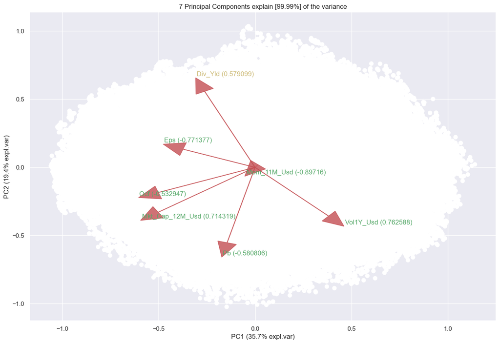

```
(<Figure size 1500x1000 with 1 Axes>,
 <AxesSubplot:title={'center':'7 Principal Components explain [99.99%] of the variance'}, xlabel='PC1 (35.7% expl.var)', ylabel='PC2 (19.4% expl.var)'>)
```

```python
from pca import pca
model = pca(n_components=7)                                                               # Initialize
results = model.fit_transform(training_sample[features_short], col_labels=features_short) # Fit transform and include the column labels and row labels
model.biplot(n_feat=7, PC=[0,1],cmap=None, label=None, legend=False)                      # Make biplot
```

图 15.2：二维 PCA 的可视化表示。

一旦旋转已知，就可以选择变换后数据的一个子样本。从原始 7 个特征中，只取 4 个很容易。

```python
pd.DataFrame(                                                   # Using DataFrame format
    np.matmul(                                                  # Matrix product using numpy
    training_sample[features_short].values,P.values[:, :4]),    # Matrix values
    columns=['PC1','PC2','PC3','PC4']                           # Change column names
    ).head()                                                    # Show first 5 lines
```

|  | PC1 | PC2 | PC3 | PC4 |
| --- | --- | --- | --- | --- |
| 0 | -0.591998 | -0.177306 | 0.058881 | -0.349897 |
| 1 | -0.043180 | -0.718323 | -0.510459 | -0.050138 |
| 2 | -1.104983 | -0.429470 | 0.023240 | -0.171445 |
| 3 | -0.376485 | -0.418983 | -0.650190 | -0.081842 |
| 4 | -0.018831 | -0.581435 | 0.242719 | -0.358501 |

这 4 个因子随后可作为正交特征输入任何机器学习引擎。特征不相关无疑是一个优点。但这种便利的代价很高：特征不再能直接解释。对预测变量去相关，会给算法再增加一层*“黑箱化”*。

PCA 也可用于估计因子模型。在式 (15.3) 中，只需将 $\textbf{Z}$ 替换为收益率，将 $\textbf{X}$ 替换为因子值，并将 $\textbf{P}$ 替换为因子载荷（早期参考可见 Connor and Korajczyk (1988)）。最近，Lettau and Pelger (2020a) 与 Lettau and Pelger (2020b) 对 PCA 估计技术进行了深入分析。他们特别指出，收益率的一阶矩很重要，应与二阶矩优化一起纳入目标函数。

本小节最后给出一个技术说明。通常，PCA 在收益率协方差矩阵上执行。有时，分解**相关**矩阵可能更合适。如果变量方差差异很大（在股票空间中通常并非如此），结果可能会显著调整。如果投资范围包含多个资产类别，那么基于相关矩阵的 PCA 会降低最高波动资产类别的重要性。在这种情况下，就好像所有收益率都按各自波动率进行了缩放。

### 15.2.3 自编码器

在 PCA 中，从 $\textbf{X}$ 到 $\textbf{Z}$ 的编码是直接的、线性的，并且双向成立： \begin{equation} \textbf{Z}=\textbf{X}\textbf{P} \quad \text{and} \quad \textbf{X}=\textbf{YP}', \end{equation}

因此可以从 $\textbf{Z}$ 恢复 $\textbf{X}$。这也可以换一种方式写成：

\begin{equation} \tag{15.5} \textbf{X} \quad \overset{\text{encode via }\textbf{P}}{\longrightarrow} \quad \textbf{Z} \quad \overset{\text{decode via } \textbf{P}'}{\longrightarrow} \quad \textbf{X} \end{equation}

如果采用截断版本并寻求更小的输出（只有 $K′$ 列），则得到：

\begin{equation} \tag{15.6} \textbf{X}, \ (I\times K) \quad \overset{\text{encode via }\textbf{P}_{K'}}{\longrightarrow} \quad \tilde{\textbf{X}}, \ (I \times K') \quad \overset{\text{decode via } \textbf{P}'_{K'}}{\longrightarrow} \quad \breve{\textbf{X}},\ (I \times K), \end{equation}

其中 $\textbf{P}_{K'}$ 是 $\textbf{P}$ 中对应最大方差因子的 $K′$ 列限制。矩阵维度标在括号内。在这种情况下，重编码无法精确恢复 $\textbf{P}$，只能得到一个近似，我们记为 $\breve{\textbf{X}}$。该近似用更少的信息编码，因此这个新数据 $\breve{\textbf{X}}$ 是压缩后的，并为原始样本 $\textbf{X}$ 提供了一个简约表示。

自编码器将这一概念推广到**非线性**编码函数。简单线性自编码器与潜在因子模型相关（单层自编码器情形参见 Proposition 1）。其结构如下：

\begin{equation} \tag{15.7} \textbf{X},\ (I\times K) \quad \overset{\text{encode via } N} {\longrightarrow} \quad \tilde{\textbf{X}}=N(\textbf{X}), \ (I \times K') \quad \overset{\text{decode via } N'}{\longrightarrow} \quad \breve{\textbf{X}}=N'(\tilde{\textbf{X}}), \ (I \times K), \end{equation}

其中编码函数和解码函数 $N$ 与 $N′$ 通常取为神经网络。**自编码器**一词来自这样一个事实：目标输出（通常记作 $\textbf{Z}$）就是原始样本 $\textbf{X}$。算法在学习编码函数 $N$ 时同步训练解码器，使输入 $\textbf{X}$ 与重构值 $\breve{\textbf{X}}$ 之间的距离（待定义）最小。编码器生成 $\textbf{X}$ 的另一种表示，解码器则尝试由该表示重构原始值。中间的编码表示 $\tilde{\textbf{X}}$ 通常具有比 $\textbf{X}$ 更低的维度。

## 15.2.4 应用

自编码器在 Keras 中很容易编写（关于 Keras 的更多细节见第 7 章）。为突出该框架的能力，我们采用另一种编写神经网络的方式：所谓 functional API。为简单起见，我们使用较少数量的预测变量（7 个）。网络结构由两个对称网络构成，只有一个包含 32 个单元的中间层。激活函数为 sigmoid；由于输入值位于单位区间内，这样做是合理的。

```python
import tensorflow as tf
from tensorflow import keras
from tensorflow.keras import layers, Input
from plot_keras_history import show_history, plot_history

input_layer = Input(shape=(7,))                                               # features_short has 7 columns
encoder = tf.keras.layers.Dense(units=32, activation="sigmoid")(input_layer)  # First, encode
encoder = tf.keras.layers.Dense(units=4)(encoder)                             # 4 dimensions for the output layer (same as PCA example)
decoder = tf.keras.layers.Dense(units=32, activation="sigmoid")(encoder)      # Then, from encoder, decode
decoder = tf.keras.layers.Dense(units=7)(decoder)                             # the original sample has 7 features
```

在训练部分，我们优化 MSE，并使用 Adam 更新权重（见第 7.2.3 节）。

```python
ae_model = keras.Model(input_layer, decoder)      # Builds the model
ae_model.compile(                                 # Learning parameters
    optimizer='adam',
    loss='mean_squared_error',
    metrics='mean_squared_error')
```

最后，我们可以把数据训练到其自身上！训练样本和测试样本上的损失演化见图 15.3。下降形态显示压缩质量在不断提升。

```
(<Figure size 1000x500 with 2 Axes>,
 array([<AxesSubplot:title={'center':'Loss'}, xlabel='Epochs', ylabel='Loss'>,
        <AxesSubplot:title={'center':'MSE'}, xlabel='Epochs', ylabel='MSE'>],
       dtype=object))
```

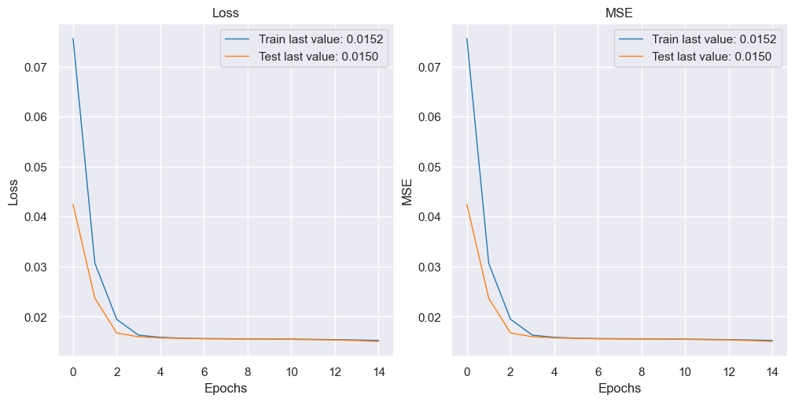

```python
history=ae_model.fit(NN_train_features, # Input
                     NN_train_features, # Output
                epochs=15,
                batch_size=512,
                validation_data=(NN_test_features, NN_test_features))
plot_history(history)
```

图 15.3：自编码器训练的输出。

要获取所有权重和偏置的细节，语法如下。

```python
ae_weights=ae_model.get_weights()
```

取回编码器并将数据处理为压缩格式，本质上只是矩阵操作。在实践中，可以通过加载编码器权重来构建一个子模型（见下方练习）。

## 15.3 k 均值聚类

第二类无监督工具与聚类有关。特征被归入同质的预测变量族。随后可以从每组中挑选一个特征（或构造它们的合成平均）。从机制上看，预测变量数量因此减少。

其原理很简单：在一组变量（若在另一个维度上针对观测值，推理相同）$\textbf{x}_{\{1 \le j \le J\}}$ 中，寻找 $k<J$ 个组的组合，使下式最小：

\begin{equation} \tag{15.8} \sum_{i=1}^k\sum_{\textbf{x}\in S_i}||\textbf{x}-\textbf{m}_i||^2, \end{equation}

其中 $||\cdot ||$ 是某种范数，通常取为欧氏 $l^2$ 范数。$S_i$ 是组，最小化在整个组集合 $\textbf{S}$ 上进行。$\textbf{m}_i$ 是组均值（也称为中心或重心）：$\textbf{m}_i=(\text{card}(S_i))^{-1}\sum_{\textbf{x}\in S_i}\textbf{x}$

若要保证得到全局最优解，就必须测试所有可能的分组；当 $k$ 和 $J$ 很大时，这在计算上几乎不可行。因此，实践中通常采用 Lloyd 算法一类的迭代式启发方法，收敛到未必全局最优、但通常“足够好”的局部解。

一种启发式做法如下：

1. 从一个（可能随机的）$k$ 个聚类划分开始。
2. 对每个聚类，计算使表达式 (15.8) 最小的最优均值 $\textbf{m}_i^*$。这是一个简单的二次规划。
3. 给定最优中心 $\textbf{m}_i^*$，重新分配点 $\textbf{x}_i$，使它们都归到最近的中心。
4. 重复步骤 1 和 2，直到点在步骤 2 中不再改变聚类。

下面用一个例子说明这一过程。我们从全部 93 个特征中构建 10 个聚类。

```python
from sklearn import cluster

k_means = cluster.KMeans(n_clusters=10)                                                     # setting the number of cluster
k_means.fit(training_sample[features].T)                                                    # Performs the k-means clustering
clusters = pd.DataFrame([features, k_means.labels_],index=["factor", "cluster"]).T          # Organize the cluster data
clusters.loc[clusters['cluster']==4,:]                                                      # Shows one particular group
```

|  | factor | cluster |
| --- | --- | --- |
| 6 | Capex_Ps_Cf | 4 |
| 19 | Eps | 4 |
| 20 | Eps_Basic | 4 |
| 21 | Eps_Basic_Gr | 4 |
| 22 | Eps_Contin_Oper | 4 |
| 23 | Eps_Dil | 4 |
| 68 | Op_Prt_Margin | 4 |
| 69 | Oper_Ps_Net_Cf | 4 |
| 80 | Sales_Ps | 4 |

我们单独查看第四个聚类，它主要由与 EPS 相关的会计比率组成。给定这 10 个聚类后，可以构建一个小得多的特征组，再将其输入第 5 至第 9 章介绍的预测引擎。聚类的代表可以是最接近中心的成员，也可以直接是中心本身。为避免信息泄漏，聚类结构必须只用训练数据拟合，再原样应用于测试数据：若每簇选一个代表特征，测试集沿用同一组列；若使用簇中心或合成指标，则沿用训练阶段确定的分组与变换，而不在测试集上重新聚类。

## 15.4 最近邻

据我们所知，最近邻并未用于大规模投资组合选择应用，原因很简单：计算成本。不过，邻域概念在无监督学习和局部可解释性分析中都很常见。需要区分的是：仅按特征寻找邻居不需要标签；一旦利用邻居的标签进行分类或回归，k 近邻（k-NN）就是监督学习方法。关于 k-NN 分类误差率上界的理论结果，可见 Ripley (2007) 第 6.2 节。其逻辑如下。如果：

1. 训练样本能够准确覆盖 $(\textbf{y}, \textbf{X})$ 的分布；**并且**
2. 测试样本与训练样本服从相同分布（或足够接近）；

那么，对于测试集中的某个样本 $\textbf{x}_i$，依据训练样本确定的邻域将为 $y_i$ 提供有价值的信息。

因此，下文将寻找某个具体样本 $\textbf{x}_i$（一个 $K$ 维行向量）的近邻。需要注意，这与上一节有一个重要区别：这里是在样本维度（行）寻找相似性，而不是在预测变量维度（列）聚类。

给定一个具有相同（对应）列 $\textbf{X}_{i,k}$ 的数据集，邻居通过相似性度量（或距离）定义：

\begin{equation} \tag{15.9} D(\textbf{x}_j,\textbf{x}_i)=\sum_{k=1}^Kc_k d_k(x_{j,k},x_{i,k}), \end{equation}

其中距离函数 $d_k$ 可作用于不同数据类型（数值型、类别型等）。对数值，$d_k(x_{j,k},x_{i,k})=(x_{j,k}-x_{i,k})^2$ 或 $d_k(x_{j,k},x_{i,k})=|x_{j,k}-x_{i,k}|$。对类别值，可参考 Boriah, Chandola, and Kumar (2008) 的详尽综述，其中列出 14 种可能度量。最后，式 (15.9) 中的 $c_k$ 通过给特征加权提供一定灵活性。这很有用，因为原始值（$x_{i,k}$ 与 $x_{i,k'}$）或度量输出（$d_k$ 与 $d_{k'}$）可能具有不同尺度。

在整个样本上计算距离后，使用索引 $l_1^i, \dots, l_I^i$ 对它们排序：

\begin{align} D\left(\textbf{x}_{l_1^i},\textbf{x}_i\right) \le D\left(\textbf{x}_{l_2^i},\textbf{x}_i\right) \le \dots, \le D\left(\textbf{x}_{l_I^i},\textbf{x}_i\right) \end{align}

最近邻是由 $l_m^i$（$m=1,\dots,k$）索引的那些样本。为简单起见，我们略去 $D\left(\textbf{x}_{l_m^i},\textbf{x}_i\right)=D\left(\textbf{x}_{l_{m+1}^i},\textbf{x}_i\right)$ 这类相等所带来的问题；只要有足够多的数值预测变量，它们在实践中很少出现。

找到这些近邻后，就可以构造对标签 $y_i$ 的预测。逻辑很直接：如果 $\textbf{x}_i$ 与其他样本 $\textbf{x}_j$ 接近，那么 $y_i$ 也应接近 $y_j$，前提是这些特征确实包含关于标签 $y$ 的预测信息。

对 $y_i$ 的一种直观预测是如下加权平均：

\begin{align} \hat{y}_i=\frac{\sum_{j\neq i} h(D(\textbf{x}_j,\textbf{x}_i)) y_j}{\sum_{j\neq i} h(D(\textbf{x}_j,\textbf{x}_i))}, \end{align}

其中 $h$ 是一个递减函数。因此，$\textbf{x}_j$ 离 $\textbf{x}_i$ 越远，其在平均中的权重越小。$h$ 的一个典型选择是 $h(z)=e^{-az}$，其中参数 $a$ 决定距离 $D(\textbf{x}_j,\textbf{x}_i)$ 的惩罚强度。当然，平均可以只在 $k$ 个最近邻集合中计算，此时 $h$ 在某个距离阈值之外等于零：

\begin{align} \hat{y}_i=\frac{\sum_{j \text{ neighbor}} h(D(\textbf{x}_j,\textbf{x}_i)) y_j}{\sum_{j \text{ neighbor}} h(D(\textbf{x}_j,\textbf{x}_i))}. \end{align}

一种假设更少的规则是在邻居集合上取 $h:=1$，此时所有邻居权重相同（分类情形下的早期讨论见 T. Bailey and Jain (1978)）。对于分类任务，该过程涉及投票规则：票数最多的类别获胜，并可配合打破平局的方法。感兴趣的读者可参阅 Bhatia et al. (2010) 的简短综述。

关于最优 $k$ 的选择，存在若干复杂技术和准则（例如见 Ghosh (2006) 与 Hall et al. (2008)）。启发式取值通常表现不错。一条经验法则是取 $k=\sqrt{I}$（$I$ 为样本总数）；除非 $I$ 极其庞大，这个取值通常不会偏离最优值太远。

下面说明这一概念。我们选取一个日期（2006 年 12 月 31 日）并挑出一只资产（stock_id 等于 13）。然后寻找在该特定日期与这只资产最接近的 $k=30$ 只股票。

```python
from sklearn import neighbors as nb             # Package for Nearest Neighbors detection

knn_data = data_ml.loc[data_ml['date']=='2006-12-31',:]          # Dataset for k-NN exercise
knn_target = knn_data.loc[knn_data['stock_id'] == 13, features]  # Target observation
knn_sample = knn_data.loc[knn_data['stock_id'] != 13, features]  # All other observations
neighbors = nb.NearestNeighbors(n_neighbors=30)       # Number of neighbors to use
neighbors.fit(knn_sample)
```

```
NearestNeighbors(n_neighbors=30)
```

```python
neigh_dist, neigh_ind = neighbors.kneighbors(knn_target)
print(pd.DataFrame(neigh_ind))                              # Indices of the k nearest neighbors
```

```
   0   1   2    3    4   5    6    7   8    9   ...   20  21   22   23   24  \
0   9   8  99  185  294  21  266  180  23  191  ...  310  95  165  215  268

    25   26  27   28   29
0  194  103  17  117  539

[1 rows x 30 columns]
```

得到近邻及其距离后，就可以预测目标股票的收益率。这里使用函数 $h(z)=e^{-z}$ 按距离为样本赋权。

```python
knn_labels = knn_data.loc[:, 'R1M_Usd'].values[neigh_ind]                   # y values for neigh_ind
np.sum(knn_labels * np.exp(-neigh_dist)/np.sum(np.exp(-neigh_dist)))        # Pred w. k(z)=e^(-z)
```

```
0.03092438258317905
```

```python
knn_data.loc[knn_data['stock_id'] == 13, 'R1M_Usd']                         # True y
```

```
96734    0.089
Name: R1M_Usd, dtype: float64
```

该预测既不算很好，也不算很差（方向是正确的！）。不过请注意，这个例子不能用于真正预测，因为我们使用 2006-12-31 的数据来预测同一天的收益。为避免前视偏差，knn_sample 变量应从更早的时间点选取。

上述计算很快（最多几秒），但只针对一只资产。在 $k$-NN 练习中，每只股票都会得到定制预测，且每次都必须重新评估邻居集合。对 $N$ 只资产，需要评估 $N(N-1)/2$ 个距离。在回测中，这尤其昂贵，特别是还要测试多个参数时（邻居数量 $k$，或加权函数 $h(z)=e^{-az}$ 中的 $a$）。当投资范围较小（例如交易指数）时，k-NN 方法在计算上更具吸引力（例如见 Chen and Hao (2017)）。

## 15.5 编程练习

通过自编码器的编码器部分，编写数据（窄训练样本）的压缩版本。

### 参考文献

Bailey, T, and A. K. Jain. 1978. “A Note on Distance-Weighted K-Nearest Neighbor Rules.” IEEE Trans. On Systems, Man, Cybernetics 8 (4): 311–13.

Bhatia, Nitin, and others. 2010. “Survey of Nearest Neighbor Techniques.” arXiv Preprint, no. 1007.0085.

Boriah, Shyam, Varun Chandola, and Vipin Kumar. 2008. “Similarity Measures for Categorical Data: A Comparative Evaluation.” In Proceedings of the 2008 Siam International Conference on Data Mining, 243–54.

Chen, Yingjun, and Yongtao Hao. 2017. “A Feature Weighted Support Vector Machine and K-Nearest Neighbor Algorithm for Stock Market Indices Prediction.” Expert Systems with Applications 80: 340–55.

Connor, Gregory, and Robert A Korajczyk. 1988. “Risk and Return in an Equilibrium Apt: Application of a New Test Methodology.” Journal of Financial Economics 21 (2): 255–89.

Ghosh, Anil K. 2006. “On Optimum Choice of K in Nearest Neighbor Classification.” Computational Statistics & Data Analysis 50 (11): 3113–23.

Hall, Peter, Byeong U Park, Richard J Samworth, and others. 2008. “Choice of Neighbor Order in Nearest-Neighbor Classification.” Annals of Statistics 36 (5): 2135–52.

Lettau, Martin, and Markus Pelger. 2020a. “Estimating Latent Asset-Pricing Factors.” Journal of Econometrics Forthcoming.

Lettau, Martin, and Markus Pelger. 2020b. “Factors That Fit the Time Series and Cross-Section of Stock Returns.” Review of Financial Studies 33 (5): 2274–2325.

Meyer, Carl D. 2000. Matrix Analysis and Applied Linear Algebra. Vol. 71. SIAM.

Ripley, Brian D. 2007. Pattern Recognition and Neural Networks. Cambridge University Press.

脚注

1. 在实践中，这不是主要问题；由于我们处理的是服从均匀分布的特征，去均值相当于从所有特征值中减去 0.5。